# From B-splines to P-splines

Glenn Palmer

2023-02-04

## Motivation

In my previous post introducing splines, I tried to make a case for how flexible and easy-to-use bases of B-splines are for modeling nonlinear relationships. But then at the end, I casually added that the results can actually be really sensitive to the choice of both the number of knots (corresponding to the number of basis functions) and the location/spacing of the knots, and that actually you should do some sort of cross-validation/tuning approach to choose good values for these hyperparameters.

To further explore this, I’m going to use the same data from that post, with 100 x-values generated uniformly in [0,10] and corresponding y-values from
$$y_i = 3 + \cos(x_i) \sqrt x_i
- 0.05x_i^2 + \varepsilon_i, \,\,\,\,\,\,\, \varepsilon_i \sim N(0,
0.3^2).$$

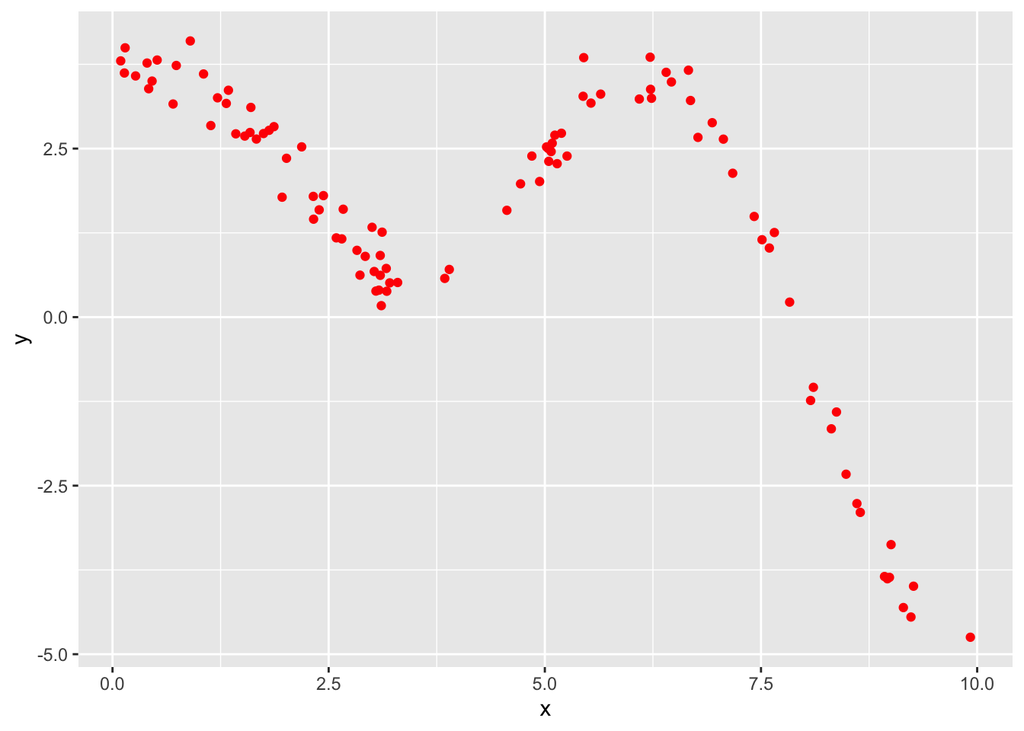

Let’s say that instead of the 6 equally-spaced B-splines I used before, I want to get a really flexible curve, so I decide to use 53 of them. Below I’ve visualized such a basis, generated by the [splines](https://www.rdocumentation.org/packages/splines/versions/3.6.2) R package.

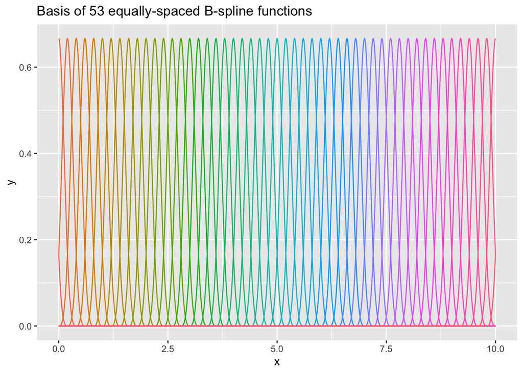

```r
library(splines)
library(reshape2)

# generate spline design matrix
visualize_mat <- splineDesign(knots = seq(-0.6, 10.6, 0.2),
                              x = seq(0,10,0.01),
                              outer.ok = TRUE)

# reshape for plotting
visualize_basis <- data.frame(visualize_mat)
visualize_basis$x <- seq(0,10,0.01)
visualize_basis <- melt(visualize_basis, id.vars="x")

# plot basis
ggplot(visualize_basis, aes(x = x, y = value, color = variable)) +
  geom_line() +
  labs(y = "y", title = "Basis of 53 equally-spaced B-spline functions") +
  theme(legend.position = "none")
```

Oh boy, this is gonna be great – with this many basis functions to work with, I think I might be able to better approximate some of the regions where my estimate with 6 B-splines was a little off. So I fit the model.

```r
# generate X matrix for observed data
X_mat <- splineDesign(knots = seq(-0.6, 10.6, 0.2),
                              x = sample_df$x,
                              outer.ok = TRUE)

# fit model
model1 <- lm(sample_df$y ~ -1 + X_mat)
model1
```

```
##
## Call:
## lm(formula = sample_df$y ~ -1 + X_mat)
##
## Coefficients:
##     X_mat1      X_mat2      X_mat3      X_mat4      X_mat5      X_mat6
## -1.132e+01   5.089e+00   3.171e+00   3.961e+00   3.002e+00   3.977e+00
##     X_mat7      X_mat8      X_mat9     X_mat10     X_mat11     X_mat12
##  3.915e+00   2.822e+00   3.305e+00   2.497e+00   3.135e+00   1.721e+00
##    X_mat13     X_mat14     X_mat15     X_mat16     X_mat17     X_mat18
##  2.774e+00   1.168e+00   1.649e+00   7.483e-01   9.669e-01   3.228e-01
##    X_mat19     X_mat20     X_mat21     X_mat22     X_mat23     X_mat24
##  1.012e+00  -7.333e+00   4.083e+03  -9.515e+03   1.339e+05  -6.383e+02
##    X_mat25     X_mat26     X_mat27     X_mat28     X_mat29     X_mat30
##  2.159e+01  -2.049e-01   3.146e+00   1.896e+00   4.002e+00   2.786e+00
##    X_mat31     X_mat32     X_mat33     X_mat34     X_mat35     X_mat36
##  4.148e+00   2.733e+00   3.763e+00   3.148e+00   4.454e+00   1.945e+00
##    X_mat37     X_mat38     X_mat39     X_mat40     X_mat41     X_mat42
##  3.425e+00   1.722e+00   1.473e+00   1.075e+00   9.877e-01  -1.780e+00
##    X_mat43     X_mat44     X_mat45     X_mat46     X_mat47     X_mat48
## -5.725e-01  -2.069e+00  -2.311e+00  -4.654e+00  -3.196e+00  -4.790e+00
##    X_mat49     X_mat50     X_mat51     X_mat52     X_mat53
## -4.494e+00   1.071e+02  -1.422e+01          NA          NA
```

Ok, there are obviously a lot more coefficients than before, but that’s fine. Except… the coefficient for the 52nd and 53rd splines are both NA…. I guess these functions are so narrow that there wasn’t enough data near x=10 to calculate an estimated $\beta_{52}$ or $\beta_{53}$. Oh well, maybe I’ll just set those coefficients to 0 and proceed anyway. Below I’ve plotted the estimated curve laid on top of the data.

```
## Warning: Removed 1 rows containing missing values (`geom_point()`).
```

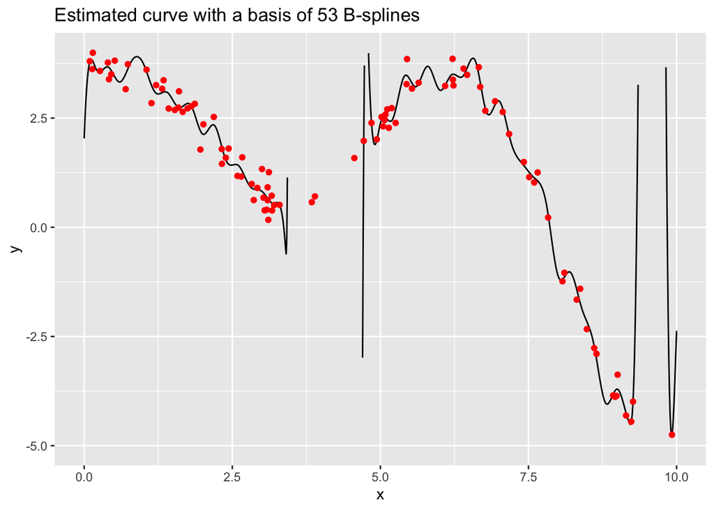

```r
# set the 52nd and 53rd coefficients to zero
model1$coefficients[52] <- 0
model1$coefficients[53] <- 0

# get estimated curve for y
y_hat <- visualize_mat %*% model1$coefficients

# plot estimated curve
viz_curve1 <- data.frame(x = seq(0,10,0.01), y = y_hat)
ggplot(viz_curve1, aes(x=x, y=y)) +
  geom_line() +
  geom_point(data=sample_df, color="red") +
  ylim(-5,4) +
  labs(title = "Estimated curve with a basis of 53 B-splines")
```

Uh oh… this doesn’t look good. Ignoring ggplot’s warning and just looking at the fitted curve, it seems like in regions with a lot of data, the splines are able to adapt so much to little variations that the curve wiggling around in response to even small amounts of noise. And then in regions without much data, things get really weird. If I get rid of the manually-set y-axis range, we see just how bad things are.

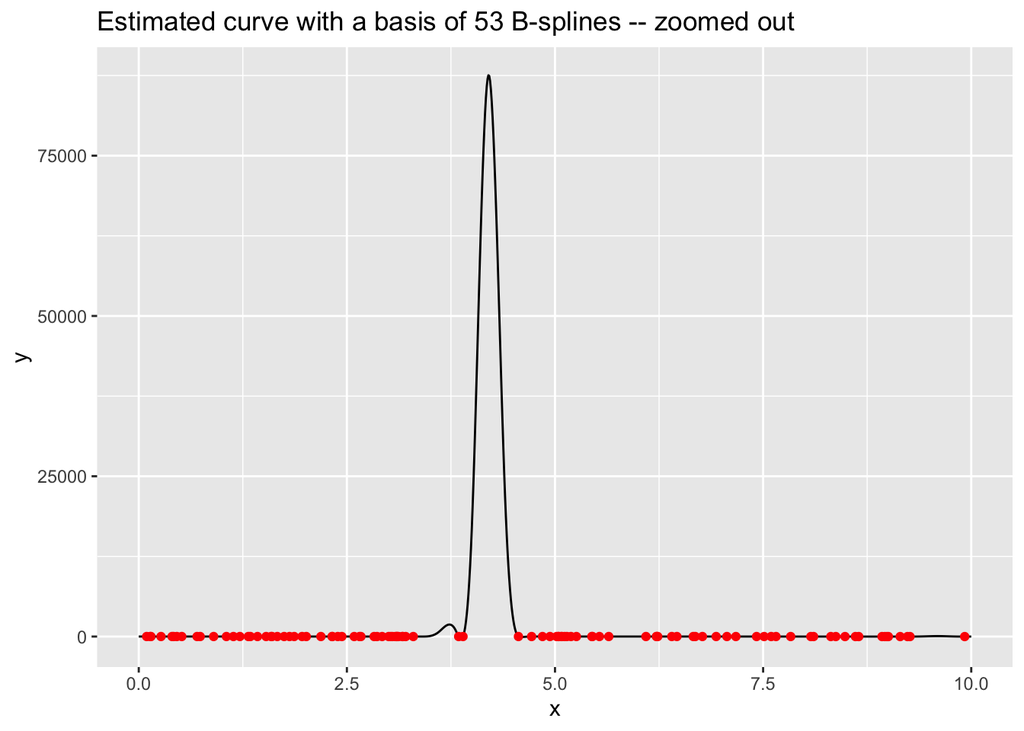

```r
# plot with default y-axis range
ggplot(viz_curve1, aes(x=x, y=y)) +
  geom_line() +
  geom_point(data=sample_df, color="red") +
  labs(title = "Estimated curve with a basis of 53 B-splines -- zoomed out")
```

It’s estimating values of like 90,000 for the region near x=4 where there’s no data observed!!!! Ok, clearly this isn’t going to work. It’s horribly overfit and going absolutely crazy when the data get even a little sparse. So, we have a couple of options:

1. Just go back to using a reasonable number of splines (e.g., 6) and fine-tune the exact number through cross-validation.
2. Stick with our ambitious basis of 53 splines, but find some way to make the estimates calm down.

If you’re happy with option 1, read no further. But clearly since I’m writing this post, I’m interested in thinking about option 2. In fact, as a teaser, I think this will turn into two posts – this one where we replace optimizing the number of splines with optimizing a different hyperparameter, and then a second post where we go Bayesian and let the data choose everything.

## P-splines!!!

Paul Eilers and Brian Marx came up with P-splines (where the P stands for “penalized”) in their [1996 paper “Flexible smoothing with B-splines and penalties.”](https://projecteuclid.org/journals/statistical-science/volume-11/issue-2/Flexible-smoothing-with-B-splines-and-penalties/10.1214/ss/1038425655.full) Since that time, in addition to being successful statisticians, they’ve been big-time P-spline evangelists. See for example the final section of [this document](https://psplines.bitbucket.io/Support/WhyPsplines.pdf) (located on their [P-spline website](https://psplines.bitbucket.io/) accompanying their [P-spline book](https://www.amazon.com/Practical-Smoothing-Paul-H-C-Eilers/dp/1108482953)) where they call out all the doubters and haters.

### How do P-splines work?

The idea behind P-splines is super simple – it’s one of many examples in statistics of using regularization to keep unstable coefficient estimates under control. (Other prominent examples include lasso and ridge regression.) To implement this regularization, we just add some additional terms in the function we optimize to get our estimates of $\beta_1, ..., \beta_{53}$. Without these terms, when we just use “lm” as I did above, we’re finding the OLS estimate $\hat{\beta}$ for the coefficients by solving

$$\hat{\beta} = \arg \min_\beta ||y - X\beta ||^2.$$

The most standard implementation of P-splines takes the above and adds penalties involving the squared difference between each consecutive pair of $\beta_j$ and $\beta_{j+1}$. Letting J be the number of B-spline basis functions and $\lambda$ be a value of our choosing (we’ll talk more about $\lambda$ later), the P-spline estimated coefficients are found by solving

$$\hat{\beta} = \arg \min_\beta \left(||y - X\beta ||^2 + \lambda
\sum_{j=1}^{J-1} (\beta_{j+1} - \beta_j)^2\right).$$

If we define a matrix $D$ as
$$D = \begin{pmatrix}
-1 & 1 & 0 & \cdots & 0 & 0\\
0 & -1 & 1 & 0 & \cdots & 0\\
\vdots & & \ddots & \ddots & & \vdots\\
0 & \cdots & 0 & -1 & 1 & 0\\
0 & \cdots & \cdots & 0 & -1 & 1
\end{pmatrix}
\in \mathbb{R}^{(J-1) \times J}$$

we can rewrite the above optimization problem using just matrices and vectors as
$$\hat{\beta} = \arg \min_\beta \left(||y - X\beta ||^2 + \lambda
||D\beta||^2 \right).$$

Finally, with a little calculus, we can find $\hat{\beta}$ by just setting the first derivative to zero.

$$\begin{align}
\frac{\partial}{\partial \beta} \left(||y - X\beta ||^2 + \lambda
||D\beta||^2 \right) & = \frac{\partial}{\partial \beta} \left( y^T
y - 2 \beta^T X^T y + \beta^T X^T X \beta + \lambda \beta^T D^T D \beta
\right) \\
&= \frac{\partial}{\partial \beta} \left(y^T y - 2 \beta^T X^T y +
\beta^T (X^T X + \lambda D^T D) \beta\right) \\
&= -2 X^T y + 2(X^T X + \lambda D^T D)\beta \\
&= 0
\end{align}$$
which yields the estimate

$$\hat{\beta} = (X^T X + \lambda D^T D)^{-1} X^T y.$$

Nice! So we just choose a value of $\lambda$ – higher values correspond to heavier penalties – and then we have a nice little formula to calculate our estimated coefficients.

### How well do P-splines work?

Hopefully the idea of P-splines makes some sense in theory (if not, it might be worth thinking a little more about what impact the added penalty terms will have on $\hat{\beta}$). But none of that matters if it doesn’t perform well on actual data. Let’s try a few values of $\lambda$ and see if adding the penalty terms can salvage our basis of 53 B-splines from earlier.

First, I need to define the matrix D.

```r
# define 52x53 matrix D
D <- matrix(data = rep(0, 52*53), nrow=52)
for (i in 1:nrow(D)) {
  D[i, i] <- -1
  D[i, i+1] <- 1
}
```

Now, let’s start out with a pretty light penalty by setting $\lambda$ to 0.1. Below, I found the corresponding $\hat{\beta}$ estimate and plotted the resulting curve.

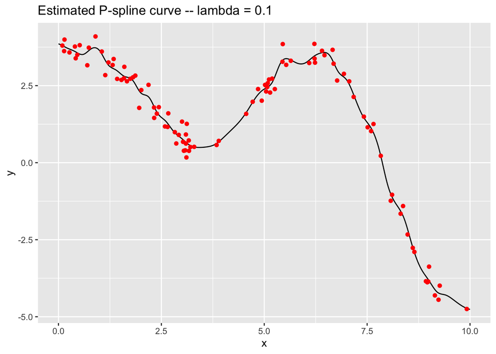

```r
# calculate beta_hat for lambda = 0.1
lambda <- 0.1
beta_hat0.1 <- solve(t(X_mat) %*% X_mat + lambda * t(D) %*% D) %*%
  t(X_mat) %*% y_sample

# get estimated curve for y
y_hat0.1 <- visualize_mat %*% beta_hat0.1

# plot estimated curve
viz_curve1 <- data.frame(x = seq(0,10,0.01), y = y_hat0.1)
ggplot(viz_curve1, aes(x=x, y=y)) +
  geom_line() +
  geom_point(data=sample_df, color="red") +
  labs(title = "Estimated P-spline curve -- lambda = 0.1")
```

Ok! It’s still probably more wiggly than I’d like, but at least it’s giving something reasonable. Let’s crank up the penalty a little more, letting $\lambda$ take on values of 1, 10, 100, and 1000.

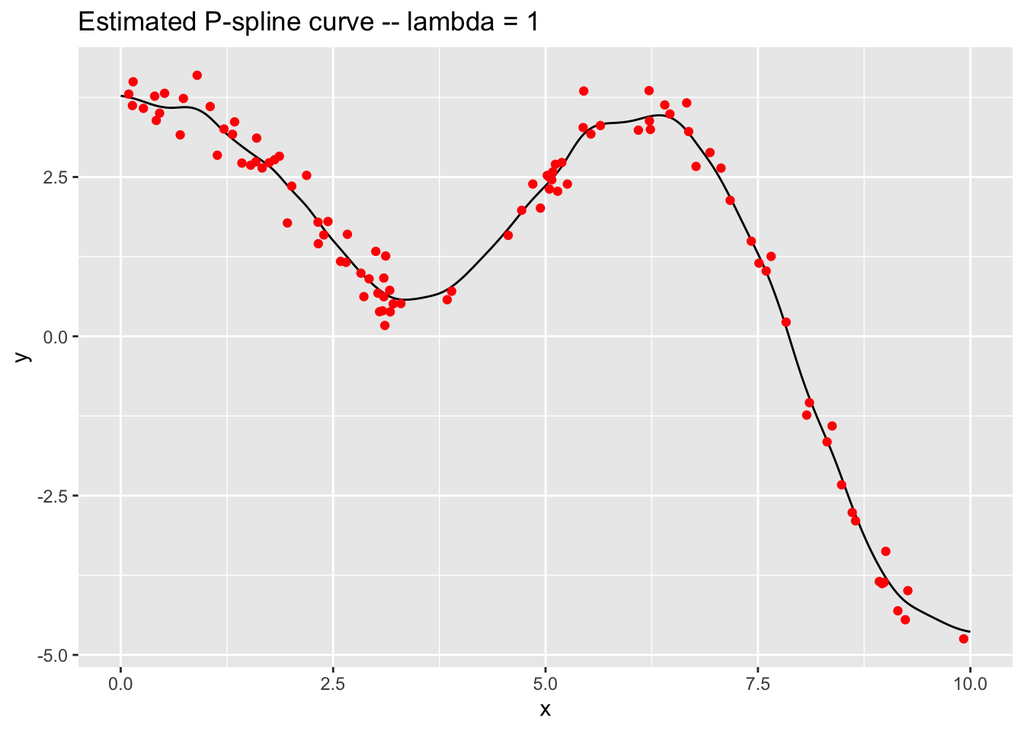

```r
# define function to plot estimated curve for different values of lambda
plot_y <- function(lambda, showdata = TRUE, showfunction = FALSE) {
  # calculate beta_hat for the given value of lambda
  beta_hat <- solve(t(X_mat) %*% X_mat + lambda * t(D) %*% D) %*%
    t(X_mat) %*% y_sample

  # get estimated curve for y
  y_hat <- visualize_mat %*% beta_hat

  # plot estimated curve
  viz_curve1 <- data.frame(x = seq(0,10,0.01), y = y_hat)
  p <- ggplot(viz_curve1, aes(x=x, y=y)) +
    geom_line() +
    labs(title = paste0("Estimated P-spline curve -- lambda = ", lambda))

  if (showdata == TRUE) {
    p <- p + geom_point(data=sample_df, color="red")
  }
  if (showfunction == TRUE) {
    p <- p + geom_line(data = curve_df, color="red") +
      labs(title = paste0("Estimated P-spline with lambda=", lambda, " (black) with actual curve\nused to generate data (red)"))
  }
  print(p)
}

plot_y(lambda = 1)
```

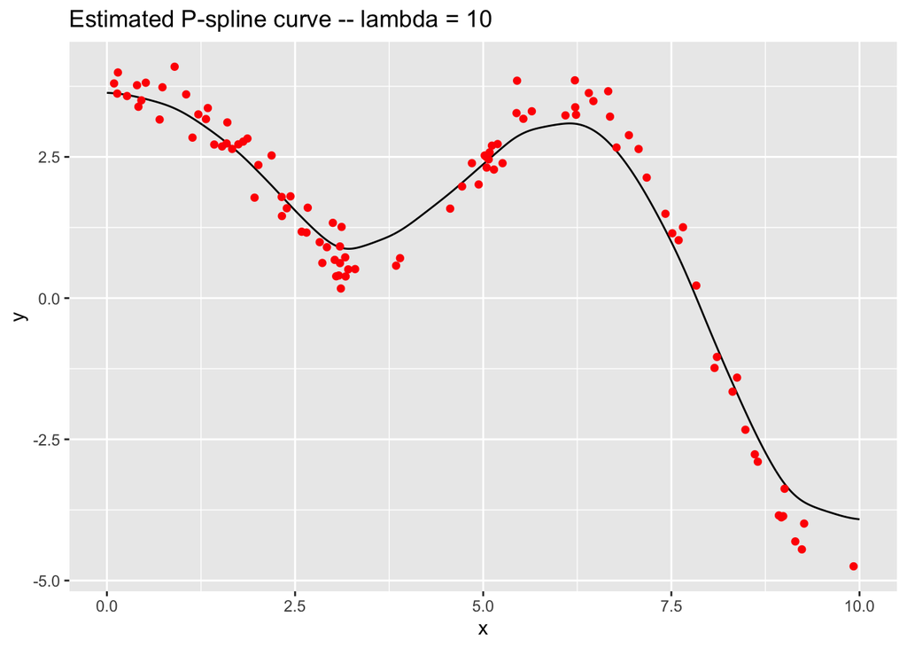

```r
plot_y(lambda = 10)
```

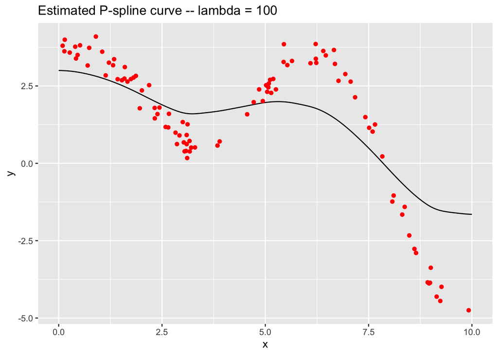

```r
plot_y(lambda = 100)
```

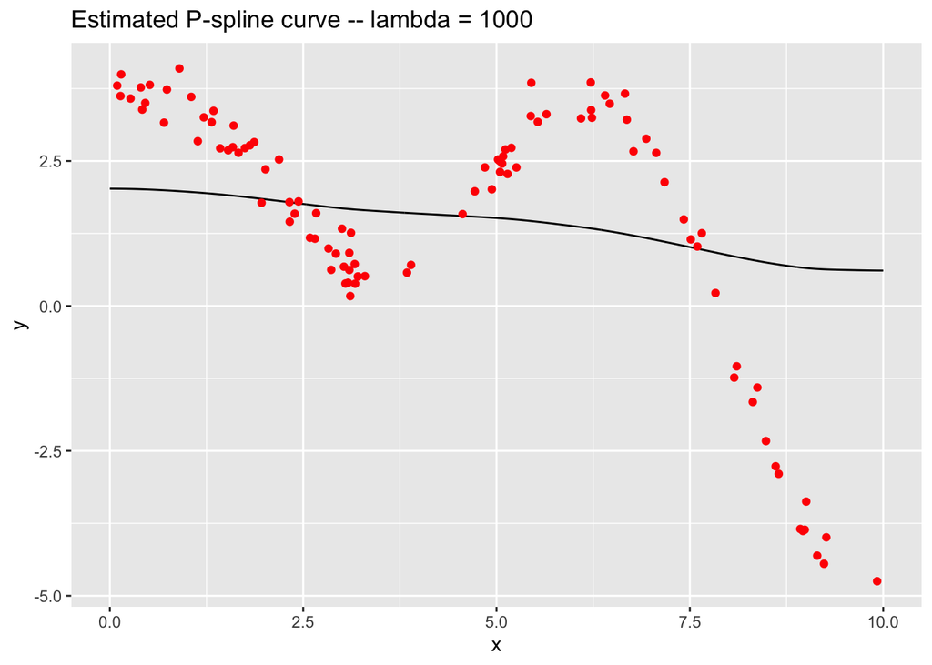

```r
plot_y(lambda = 1000)
```

Note the difference in the curves as we increase $\lambda$. For $\lambda = 1$, things are starting to look pretty nice. For $\lambda = 10$, the curve is even smoother, but it may actually be a little oversmoothed and not fitting the data quite as well. Then for $\lambda$ values of 100 and 1000, the penalty terms start completely dominating and the curve doesn’t fit the data well at all.

Thus, as before, we haven’t completely escaped having to manually choose hyperparameter values – you could argue we’ve just kicked the can down the road (for now) from having to fine-tune the number and placement of knots to having to fine-tune the value of $\lambda$. At this point, we’d want to use some process of cross-validation searching over $\lambda$ values in a range of say 1 to 5, and select the best fit in terms of predictive ability. With that said, let’s just stick with $\lambda = 1$ for now and compare to the function used to generate the data.

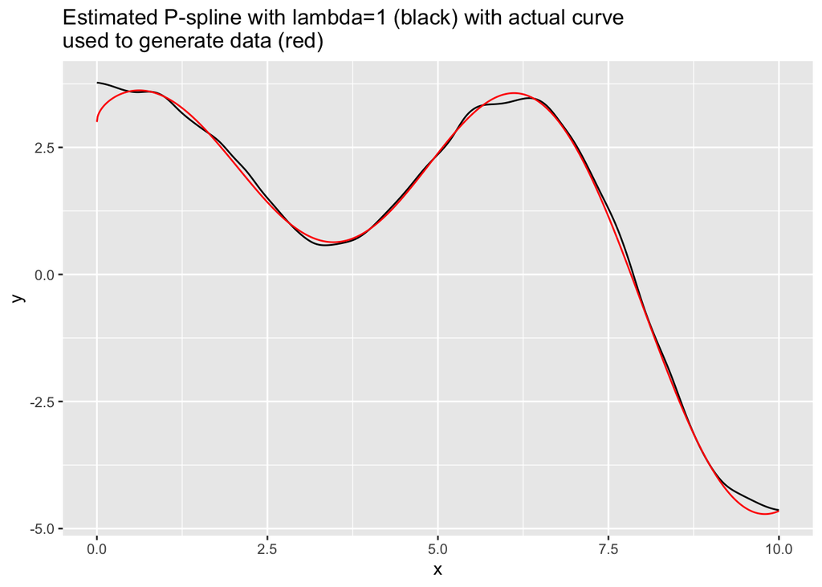

```r
plot_y(lambda = 1, showdata = FALSE, showfunction = TRUE)
```

There’s still some disagreement near x=0, but comparing with the data, that seems to just be a sampling issue. But when we compare the agreement in the middle of the graph to the fit we had using 6 unpenalized B-splines shown below, it looks solidly better for the P-splines.

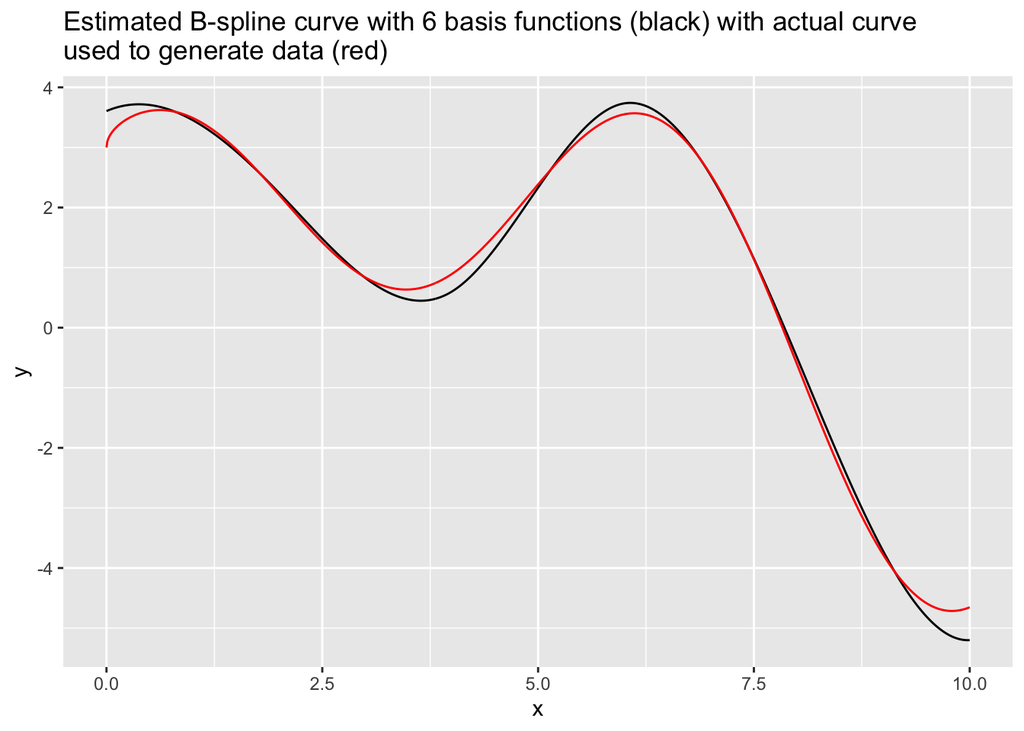

## Summary

In this post, we took the general framework of B-splines and gave a shot at eliminating the need to fine-tune the number and placement of basis functions by adding a penalty. It appears we were able to improve the fit to the data some by this change in approach, but we didn’t totally eliminate the need for hyperparameter tuning. For an attempt at true freedom from hyperparameters, stay tuned for the next post.

## Bibliography

Eilers, Paul HC, and Brian D Marx. 1996. “Flexible Smoothing with b-Splines and Penalties.” *Statistical Science* 11 (2): 89–121.

Eilers, Paul H, and Brian D Marx. 2021. *Practical Smoothing: The Joys of p-Splines*. Cambridge University Press.

Wikipedia. 2023. “Regularization (mathematics) — Wikipedia, the Free Encyclopedia.” http://en.wikipedia.org/w/index.php?title=Regularization%20(mathematics)&oldid=1133809575.